# Spruce budworm flight phenology in Maine

Seasonal dynamics — analysis log

Author

JN Candau

Published

2 October 2026

# 1 Purpose of this document

This is the running log of the *Seasonal dynamics* analysis of spruce budworm (*Choristoneura fumiferana*) light-trap catches in Maine. Where the *Daily dynamics* analysis (`daily_dynamics/`) models the catch night by night, this one treats each locality-year as a single observation — when its flight season was centred, how long it lasted and how it was shaped — and asks how those quantities depend on temperature.

The two analyses share one dataset. Its rules are set once, in the data layer at the project root (`R/01_read_trap_data.R`, `R/02_read_weather_data.R`), and hold identically here:

- the season of each year runs from the first to the last night on which any trap caught a moth that year;
- a `-` cell inside that window is a night the trap ran and caught nothing, i.e. a zero;
- an `m` cell is a night whose count was lost, and stays missing;
- one record (Elliotsville Township 1978) is excluded because its only missing nights fell at the peak of its season.

The data layer also holds the two development-model runs used below, BioSIM (`R/03_biosim_phenology.R`) and bayessbw (`R/04_pupal_phenology.R`). Nothing in this analysis reads an output of `daily_dynamics/`.

# 2 The season-level data

`seasonal_dynamics/R/01_season_percentiles.R` reduces each record to one row. The percentiles come from the cumulative catch over the counted nights, computed with the project’s shared helper (`R/functions/phenology.R`), so they are identical to those used in the daily analysis.

Table 1: The season-level response table

| Quantity | Value |
| --- | --- |
| Locality-years | 226 |
| Localities | 49 |
| Years | 22 |
| Usable for phenology | 223 |
| Median catch date, DOY: median (range) | 194.2 (176.3 to 206.6) |
| Central 90% of the season, d | 11.2 (0.9 to 38.5) |
| Central 50% of the season, d | 4.1 (0.5 to 18.1) |
| Asymmetry, d (positive = longer decline) | 0.2 (-12.9 to 14.9) |
| Share of the season on the peak night | 0.34 (0.09 to 1.00) |
| Records with right-censored nights | 4 |

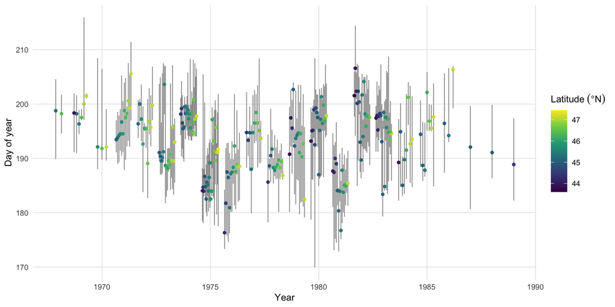

Figure 1: Flight season of every locality-year, by year. Point: median catch date; bar: central 90% of the catch (p05 to p95). Records within a year are ordered by latitude, south to north.

# 3 Predicted pupation dates

The two development models of the shared data layer predict pupation, not flight: BioSIM (`R/03_biosim_phenology.R`, mortality switched off) and bayessbw (`R/04_pupal_phenology.R`). `seasonal_dynamics/R/02_pupation_dates.R` puts both on the same footing, as a distribution of pupation dates per locality-year.

For bayessbw this is direct: the model returns the date on which each simulated individual pupates. BioSIM does not. It reports pupae as a **stock**, the share of the cohort that is a pupa on a given day, and the median of that curve is the middle of the pupal period rather than the date of pupation. The pupation-date distribution is recovered from mass balance. With mortality off, an individual that has pupated by day *t* is either still a pupa or has already emerged, so cumulative pupation is the pupae present plus the cumulative emergence, and its daily increments are the distribution.

The distinction is not cosmetic. The stock median falls a median 4.9 days after the true median pupation date, and with the true date BioSIM pupates 4.3 days *earlier* than bayessbw on average, where the stock median had put the two models within a day of each other. The two remain well correlated across locality-years (r = 0.78).

In 9 locality-years BioSIM’s pupae vanish within a day without emerging, although mortality is switched off. These are all records whose BioSIM cohort R/03 already flags as incomplete, and they leave the analysis set below. The pupation dates of the remaining records are unaffected.

# 4 The median catch date as a function of pupation

`seasonal_dynamics/R/03_median_vs_pupation.R` models the observed median catch date of 203 locality-years (20 years, 48 localities: usable for phenology, with a complete BioSIM cohort) from the predicted median pupation date, separately for each model:

- **lag**: median catch date = pupation + a constant interval;
- **linear**: median catch date = *a* + *b* x pupation;
- **split**: the predicted pupation date is divided into the mean over the localities of that year and each locality’s departure from it, each with its own slope. The year mean uses predicted dates only, so it is available at prediction time.

Each is scored twice: leaving out one year at a time, the test for a new year, and leaving out one locality at a time, the test for a new place. Two baselines give the scale. *Climatology* predicts the mean date of the training data. *Same-year* predicts the mean observed date of the other localities that year; it is not a forecast, since it uses the year being predicted, but it is the floor that any year-level model faces.

Table 2: Skill in predicting the observed median catch date (RMSE and MAE in days)

| Driver | Model | RMSE, new year | MAE, new year | RMSE, new place | MAE, new place |
| --- | --- | --- | --- | --- | --- |
| BioSIM | split | 5.19 | 4.26 | 4.96 | 4.04 |
| BioSIM | linear | 5.50 | 4.48 | 5.30 | 4.30 |
| BioSIM | lag | 6.85 | 5.52 | 6.79 | 5.46 |
| bayessbw | split | 5.05 | 4.06 | 4.83 | 3.88 |
| bayessbw | linear | 5.53 | 4.45 | 5.31 | 4.26 |
| bayessbw | lag | 6.73 | 5.13 | 6.69 | 5.12 |
| - | same-year | 3.80 | 2.74 | 3.80 | 2.74 |
| - | climatology | 5.92 | 5.03 | 5.68 | 4.79 |

**The fixed-lag model is worse than knowing nothing.** Adding a constant interval to either model’s pupation date gives an RMSE of 6.85 (BioSIM) and 6.73 days (bayessbw) for a new year, against 5.92 for the climatology.

**The split model shows why.** A year whose predicted pupation is early also flies early, with a slope of 0.70 (0.28 to 1.13) for BioSIM and 0.76 (0.38 to 1.14) for bayessbw, both compatible with one day of flight per day of pupation. But a locality whose predicted pupation is early *relative to the others that year* barely flies earlier at all: the within-year slopes are 0.11 (0.01 to 0.21) and 0.06 (-0.05 to 0.16). The models place the year correctly and the localities within it wrongly, so a fixed lag inherits the full spatial spread of the predictions, which is mostly not there in the catches. The coefficients come from mixed models with a random year intercept, because locality-years of one year share its weather.

With the split, both drivers beat the climatology for a new year (5.19 and 5.05 days) and for a new place (4.96 and 4.83), bayessbw by a small margin. Both stay well above the same-year floor of 3.80 days.

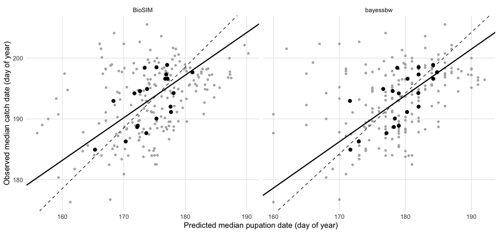

Figure 2: Observed median catch date against predicted median pupation date. Grey: locality-years. Black: year means. Solid line: the year-level slope of the split model through the year means. Dashed line: the fixed-lag model.

The year-level relationship carries the predictive skill. For a new year the split model needs only the network mean of the predicted pupation dates; the locality’s own predicted date adds almost nothing. That is the seasonal counterpart of the daily analysis, where a single regional BioSIM run beat site-specific runs.

# 5 Season width and the size of the catch

`seasonal_dynamics/R/04_width_vs_catch.R` asks whether the length of the flight season depends on how many moths the trap caught, over the 223 locality-years usable for phenology.

Table 3: Change in season width per tenfold increase in the season total (days)

| Width | Model | n | d per tenfold | 95% CI | R2 |
| --- | --- | --- | --- | --- | --- |
| central 90% | alone | 223 | -1.82 | -2.78 to -0.87 | 0.061 |
| central 90% | year fixed effects | 223 | -1.92 | -2.96 to -0.88 | 0.214 |
| central 90% | alone, >= 3 positive nights | 222 | -1.80 | -2.76 to -0.85 | 0.059 |
| central 50% | alone | 223 | -1.20 | -1.71 to -0.69 | 0.089 |
| central 50% | year fixed effects | 223 | -1.18 | -1.76 to -0.61 | 0.191 |
| central 50% | alone, >= 3 positive nights | 222 | -1.18 | -1.69 to -0.67 | 0.086 |
| central 90% | alone, sampling bias removed | 223 | -1.44 | -2.39 to -0.49 | 0.039 |
| central 50% | alone, sampling bias removed | 223 | -1.08 | -1.59 to -0.57 | 0.073 |

**Yes: larger catches have shorter seasons.** The central 90% shortens by 1.8 days per tenfold increase in catch, and the central 50% by 1.2 days. The slope is unchanged with year fixed effects and without the one season concentrated on a single night.

**Sampling explains part of it, not all.** A percentile estimated from a small catch is noisier, and on a spiky seasonal curve that noise need not average to zero. The rarefaction null measures the effect directly. Each of the 79 seasons of at least 3,000 moths is treated as a known season, 200 smaller catches are drawn from it at each size, and their widths are measured exactly as for the real data.

Table 4: Width change produced by sampling alone: catches of N moths drawn from seasons of 3,000 or more

| N moths | central 90%, d | central 50%, d |
| --- | --- | --- |
| 100 | +1.12 (sd 2.39) | +0.33 (sd 0.95) |
| 200 | +0.58 (sd 1.66) | +0.20 (sd 0.66) |
| 500 | +0.24 (sd 0.96) | +0.08 (sd 0.40) |
| 1,000 | +0.13 (sd 0.68) | +0.05 (sd 0.28) |
| 2,000 | +0.05 (sd 0.48) | +0.02 (sd 0.19) |

Small catches do come out wider, by about a day at 100 moths and by almost nothing above 1,000. Subtracting from each record the sampling bias expected at its own catch size leaves a slope of -1.44 days per tenfold for the central 90% (-2.39 to -0.49) and -1.08 for the central 50% (-1.59 to -0.57). About a fifth of the central-90% effect is sampling; the rest belongs to the seasons.

**The effect is within localities.** Over the 33 localities with at least three years, a locality’s large-catch years are shorter than its small-catch years (r = -0.24 for the central 90%, -0.34 for the central 50%). The relationship between locality means is weaker (-0.19 and -0.15). This is the opposite of the median-date offset of the daily analysis, which belonged to the locality and not to the year. Season width tracks how many moths a given season produced at a given place.

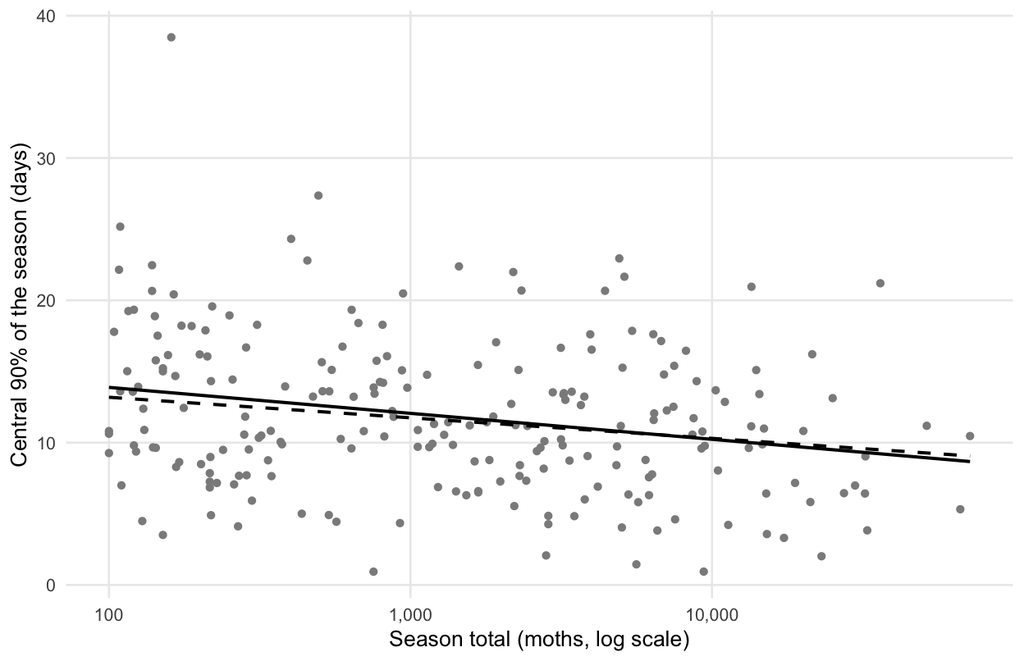

Figure 3: Width of the central 90% of the flight season against the season total. Points: locality-years. Solid line: least-squares fit to the observed widths. Dashed line: the fit after subtracting the width that sampling alone adds at each catch size.

What drives it is not established here. Two readings fit a within-locality effect: a dense population emerging more synchronously, or a season whose total is inflated by a few warm nights of mass flight, which concentrates the catch whatever the emergence. The second predicts that the effect weakens once nightly temperature is accounted for, which the daily analysis is equipped to test.

# 6 Asymmetry of the season

`seasonal_dynamics/R/05_asymmetry.R` covers the first two steps: choosing a measure and describing it. It does not yet model asymmetry.

## 6.1 The measure

The asymmetry of Section 2, (p95 - p50) - (p50 - p05), is in days. Two measures that do not depend on the length of the season replace it, both bounded between -1 and 1 and positive when the decline is longer than the rise:

- **Kelly**, (p90 + p10 - 2 p50) / (p90 - p10), over the central 80% of the catch;
- **Bowley**, (p75 + p25 - 2 p50) / (p75 - p25), over the central 50%.

Neither uses p05 or p95, the percentiles most exposed to the right-censored records and to single stray nights in the tails. Kelly is the primary measure: Bowley rests on a central 50% that is often only three or four nights wide.

The concern that motivated the change turns out not to bite. The day-based measure is uncorrelated with season width (r = +0.01), because width changes its magnitude but not its sign, and Kelly tracks it closely (r = 0.87). The scale-free measure is still the right one to model, because its value means the same thing in a ten-day season as in a thirty-day one.

## 6.2 Is the typical season skewed?

No. Over 222 locality-years (usable for phenology, at least three positive nights), the median Kelly asymmetry is +0.00 and 50% of seasons are right-skewed. A mixed model with crossed random effects of year and locality, which does not count seasons sharing a year or a place as independent, puts the mean at +0.045 (-0.020 to +0.110). Bowley gives the same answer (+0.027, -0.025 to +0.078). The flight season is symmetric on average, and individual seasons depart from symmetry in both directions.

## 6.3 Signal or noise?

Table 5: Where the variation in asymmetry lies. Variance shares from the mixed model; sampling variance from resampling every record’s own catch

| Measure | Year, % | Locality, % | Locality-year, % | Sampling sd, median | Reliability |
| --- | --- | --- | --- | --- | --- |
| Kelly | 3 | 0 | 97 | 0.037 | 0.95 |
| Bowley | 0 | 0 | 100 | 0.043 | 0.91 |

Each record’s asymmetry is estimated from a finite catch. To measure that error, 200 catches of the record’s own size were drawn from its own nightly shares and the measure recomputed. The sampling error is small (median sd 0.037 against a spread of 0.42 between seasons), so 95% of the observed variation is not counting noise.

Almost none of it belongs to the year or to the locality: 97% of the variance of Kelly is at the level of the individual locality-year. A season’s asymmetry is not inherited from its year (as the median date largely is) or from its place (as the model offsets of the daily analysis were).

What the resampling cannot see is the night-to-night variability of flight itself. It treats moths as independent draws from the season’s curve, whereas the daily analysis found nightly catches far more variable than that (NB2 θ ≈ 0.19). A single warm or cold night, or a single mass flight, moves a percentile, and that is part of the “real” variation here. The asymmetry of a season may therefore be as much a property of its weather in particular weeks as of its emergence.

## 6.4 What asymmetry goes with

Table 6: Correlation of the Kelly and Bowley asymmetry with other properties of the season

| Property | Kelly | Bowley |
| --- | --- | --- |
| width90 | -0.06 | -0.07 |
| log10 season total | -0.01 | -0.04 |
| latitude | +0.09 | +0.11 |
| median catch date | -0.30 | -0.24 |

Asymmetry is unrelated to the width of the season, to the size of the catch and to latitude. Its one clear association is with the median catch date (r = -0.30), and that association is entirely **within years**. Among localities of the same year, one that flies later than the others has a left-skewed season, a long rise and an abrupt end (r = -0.44 over 18 years). Between year means there is no relation (r = -0.05).

This is not an artefact of the season window. The asymmetry is unrelated to how close a record’s p10 or p90 comes to the first or last capture of its year.

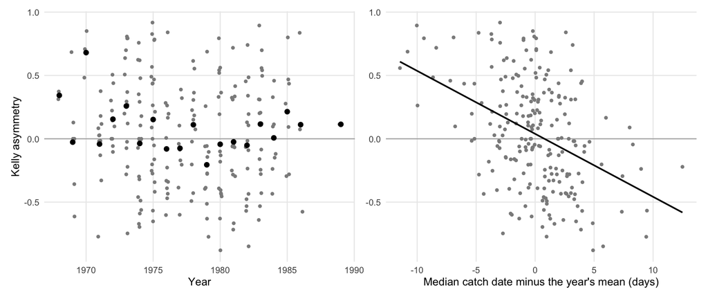

Figure 4: Kelly asymmetry of each locality-year. Left: by year; black points are year means. Right: against the locality’s departure from the mean median catch date of its year, with a least-squares line. Positive asymmetry: longer decline than rise.

Two readings fit a within-year pattern, and step 3 (Section 6.5) tests them.

- **A common end to the season.** If flight ends at about the same time everywhere in a year, for example at the first cool spell, a locality that started late has its decline cut short and an early one has room for a long tail.
- **Moths from elsewhere.** If part of the catch is moths that emerged elsewhere in the region, a late locality receives them before its own moths fly, which stretches its rise, and an early locality receives them after, which stretches its decline. That reading fits the daily analysis’s finding that one regional development curve predicts the catches better than local ones.

The first predicts that late localities share their end date with the rest of the year; the second predicts that the early part of a late locality’s catch is synchronous with the peak elsewhere. Both are testable with the data in hand.

## 6.5 Step 3: which part of the season is shared?

The two readings of Section 6, and the null, disagree about **which part of the season** is shared among the localities of a year.

Table 7: What each explanation predicts

| Hypothesis | Spread among localities, by percentile | How each percentile follows a locality’s lateness |
| --- | --- | --- |
| Pure shift | the same at every percentile | the same at every percentile |
| Common end | smaller in the late tail | weaker in the late tail |
| Regional mixing | smaller in both tails | weaker in both tails |

`seasonal_dynamics/R/06_asymmetry_mechanisms.R` measures both profiles over 219 locality-years in 18 years. The spread is the pooled within-year standard deviation of each percentile, corrected for sampling error with the same resampling as above, since tail percentiles rest on fewer moths and would otherwise look more variable. A locality’s **lateness** is its mean departure of the median catch date from its year’s mean, taken over its *other* years; that way it shares no sampling error with the season it is used to explain. Both profiles are scaled to the median, and their intervals come from a bootstrap over years.

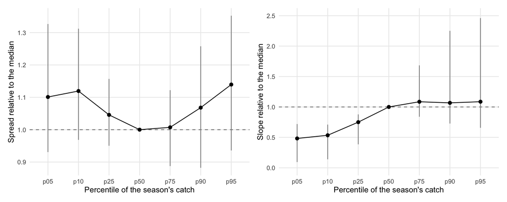

Figure 5: Left: spread of each percentile among the localities of a year, relative to the spread of the median (sampling error removed). Right: how strongly each percentile follows the locality’s lateness in its other years, relative to the median. Bars: 95% bootstrap intervals over years. Dashed line: pure shift.

**No part of the season is pinned to a common date.** Every percentile varies about equally among the localities of a year: relative to the median, the spread is 1.11 in the early tail (0.95 to 1.32) and 1.10 in the late tail (0.91 to 1.30). A common end date would have shrunk the late tail; regional mixing would have shrunk both. Neither happens.

**But lateness is lopsided.** A locality that is habitually late is late in its median and in its decline by the full amount: the late tail follows its lateness at 1.08 times the median’s slope. Its early tail follows at only 0.51 times (0.13 to 0.70), and the difference, +0.57 (+0.11 to +2.03), excludes zero. Habitually late localities start nearly as early as the others, then peak and finish late. This is a **common start** for the persistent part of lateness, the mirror image of the common-end hypothesis, and it produces the long rise of late localities found in Section 6.

The two results are compatible. Habitual lateness is only part of a locality’s departure in a given year: the slope of the median on lateness is 0.47 (0.15 to 0.87). The remainder, which is specific to the year, moves the whole season and keeps the spread profile flat.

What this rules out, and what it leaves:

- **A regional end to flight is ruled out.** Late tails are not shared and follow each locality’s own timing fully.
- **Symmetric regional mixing is ruled out.** The late tails of early localities are not pulled toward the regional dates.
- **Left standing: an early fraction of the catch at late localities that flies on the regional schedule.** It could be moths arriving from earlier areas before the local population emerges, which would be dispersal in one direction only. It could equally be local heterogeneity: warm pockets around a cool site that emerge with the rest of the region.

Geography does not separate the two here. Habitual lateness is barely related to latitude and longitude (R<sup>2</sup> = 0.07 over 33 localities with at least three years). The two most habitually early localities, Greenbush and Passadumkeag, are neighbours in the Penobscot valley, and the late ones are scattered across the state. A dispersal source would have to be identified from the timing of the early catches themselves, night by night, which is a question for the daily analysis.

## 6.6 Decision: the season is treated as symmetric

The typical season is symmetric (Section 6), its asymmetry is idiosyncratic to the locality-year, and the one systematic pattern — the early start of habitually late localities (Section 6.5) — is a within-year contrast that a model of the whole network does not need. The seasonal model therefore treats the flight season as **symmetric about its median**. Asymmetry is not modelled.

A symmetric season still needs a shape, and the ratio of the central 50% to the central 90% of the catch identifies it without fitting anything. For a normal curve the ratio is 0.410, for a logistic 0.373 and for a Laplace (double exponential) 0.301. The observed median is 0.350 (0.324 to 0.386 over 222 locality-years), and 0.326 in the seasons of 3,000 moths or more, where the percentiles are most precise. The season is more peaked, with heavier tails, than a normal curve. A logistic is consistent with the data as a whole, and the best-sampled seasons lie between the logistic and the Laplace.

# 7 A seasonal predictor

`seasonal_dynamics/R/07_seasonal_predictor.R` combines the three results above into a prediction of how a season’s catch is spread over its nights. This section develops it with the centre of Section 4, predicted pupation; Section 7.3 then replaces that centre with BioSIM flight, which is the version adopted (Section 7.4). The components are:

- **centre**: the median catch date from the split model of Section 4, the network mean of predicted pupation plus the locality’s departure from it;
- **width**: the central 90% of the season from the season total (Section 5), fitted to widths with their sampling bias removed, so that the curve describes the season and the counting noise is left to the nights;
- **shape**: symmetric about the centre (Section 6.6), with its scale set so that its central 90% equals the predicted width.

The share of night *d* is the curve’s mass between *d* - 1 and *d*, which puts its median on the same scale as the observed one. A small uniform floor (a fraction 0.001 of the season, spread over its nights) keeps every night above zero. Shares are then normalised over the record’s counted nights. Every component is refitted on the training data of each fold, leaving out one year at a time and, separately, one locality at a time. The score is the log score per moth: the summed log share of the night on which each moth was caught, divided by the number of moths. It is the log-likelihood of the nightly catch given its total, and higher is better.

## 7.1 The centre is uncertain, and the curve must say so

Table 8: Log score per moth of the seasonal predictor (logistic shape, width from the season total)

| Driver | Centre | New year | New locality | Median error, new year, d |
| --- | --- | --- | --- | --- |
| BioSIM pupation | placed as if known | -3.501 | -3.384 | 4.26 |
| BioSIM pupation | averaged over its uncertainty | -3.176 | -3.125 | 4.26 |
| bayessbw pupation | placed as if known | -3.646 | -3.528 | 4.06 |
| bayessbw pupation | averaged over its uncertainty | -3.260 | -3.183 | 4.06 |

The predicted centre misses the observed median by about four days on average. A curve placed as if its centre were exact is then too confident: a season that peaks four days from the prediction falls on nights the curve has given almost nothing. The predictive curve is the season curve **averaged over the uncertainty of its centre**: a normal error whose SD is the residual SD of the centre model in the training data, about 4.9 days. This raises the log score for a new year from -3.501 to -3.176 with BioSIM, and is the largest single gain in the predictor.

With that done, **BioSIM is the better driver** for nightly shares, for a new year (-3.176 against -3.260) and for a new locality (-3.125 against -3.183). This holds although bayessbw has the slightly smaller median error per locality-year (4.06 against 4.26 days). The log score per moth weighs each season by its catch, and weighted that way the ranking reverses: BioSIM’s median error is 4.12 days against 4.48 for bayessbw. BioSIM places the large seasons better, and those are where most of the moths are.

## 7.2 What the components are worth

Table 9: Log score per moth for a new year (BioSIM pupation, logistic, centre placed as if known) when one or both components are replaced by the observed value

| Given the observed | Log score per moth |
| --- | --- |
| nothing (the predictor) | -3.501 |
| width | -3.852 |
| centre | -2.535 |
| centre and width | -2.417 |

Almost all the room for improvement is in the centre. Knowing the observed median catch date would raise the log score from -3.501 to -2.535; knowing the width as well adds only 0.118. Knowing the observed width *alone* makes the prediction worse (-3.852). When the centre is wrong, a true, narrow season concentrates the curve on the wrong nights, whereas the predicted width, drawn toward the average, hedges the miss.

**The width model is unbiased.** Its mean error against the bias-corrected widths is +0.01 days for a new year. Adding the predicted spread of pupation as a second covariate changes nothing, so the development models carry no information about season width beyond what the catch provides.

**Shape matters little once the centre’s uncertainty is averaged in.**

Table 10: Log score per moth by shape, BioSIM pupation, centre averaged over its uncertainty

| Shape | New year | New locality |
| --- | --- | --- |
| laplace | -3.174 | -3.123 |
| logistic | -3.176 | -3.125 |
| normal | -3.179 | -3.127 |

The three shapes differ by less than 0.01. Placed as if the centre were known, the logistic clearly beat the normal, as the shape check of Section 6.6 predicted. Averaged over a four-to-five-day uncertainty in the centre, the differences in the tails no longer matter. The predictor uses the logistic, which matches the observed shape of the seasons themselves.

## 7.3 A better centre

Nearly all the predictor’s error is in its centre (Section 7). `seasonal_dynamics/R/08_centre_options.R` tries three alternatives to BioSIM pupation, each in the same split form (the network mean of the driver that year plus the locality’s departure from it) and scored on the same 203 locality-years, both alone and inside the full predictor:

- **BioSIM emergence**: the median date of adult emergence (`Emergence_mf`, added to `R/03`);
- **BioSIM flight**: the median of BioSIM’s flight series;
- **bayessbw pupation plus temperature**: the mean daily temperature at the trap over the 14 or 21 days after the locality’s predicted median pupation, split like the driver into a network-mean and a local-departure term. This is the temperature of the pupal and pre-flight period, which a pupation date cannot know.

Table 11: Centre options. Log score per moth: the full predictor (width from the season total, logistic curve averaged over the centre’s uncertainty). MAE: error of the predicted median catch date (days)

| Centre | Log score, new year | MAE, new year | RMSE, new year | Log score, new locality | MAE, new locality |
| --- | --- | --- | --- | --- | --- |
| BioSIM flight | -3.049 | 3.52 | 4.42 | -3.019 | 3.40 |
| BioSIM emergence | -3.118 | 3.87 | 4.75 | -3.078 | 3.70 |
| bayessbw pupation + T21 | -3.162 | 3.92 | 4.86 | -3.100 | 3.70 |
| bayessbw pupation + T14 | -3.173 | 3.81 | 4.83 | -3.107 | 3.61 |
| BioSIM pupation | -3.176 | 4.26 | 5.19 | -3.125 | 4.04 |
| bayessbw pupation | -3.260 | 4.06 | 5.05 | -3.183 | 3.88 |

The ranking follows how close each driver is to the moment of flight. The year-level slope rises toward one along the same sequence: pupation 0.70, emergence 0.82, flight 0.87 (0.56 to 1.17). Each step adds the part of BioSIM’s biology, from pupation through the pupal stage and adult maturation to flight, that the catches confirm. The within-year slopes stay near 0.1 for every driver (0.12 for flight): none of them recovers the differences between localities of the same year.

**Temperature after pupation helps bayessbw, but not enough.** Adding the post-pupation temperature to bayessbw raises its log score for a new year from -3.260 to -3.173 (14 days) and -3.162 (21 days). That still falls short of BioSIM emergence, let alone flight. The temperature works through the year: a year warmer by 1 °C after pupation flies 1.5 days earlier (-3.0 to 0.1, 14-day window). A locality warmer than the others that year flies only 0.21 days earlier per degree (-0.68 to 0.25). The local response is again the missing piece. BioSIM, which simulates the pupal stage and adult maturation explicitly, already does better with that temperature than an empirical correction added to bayessbw.

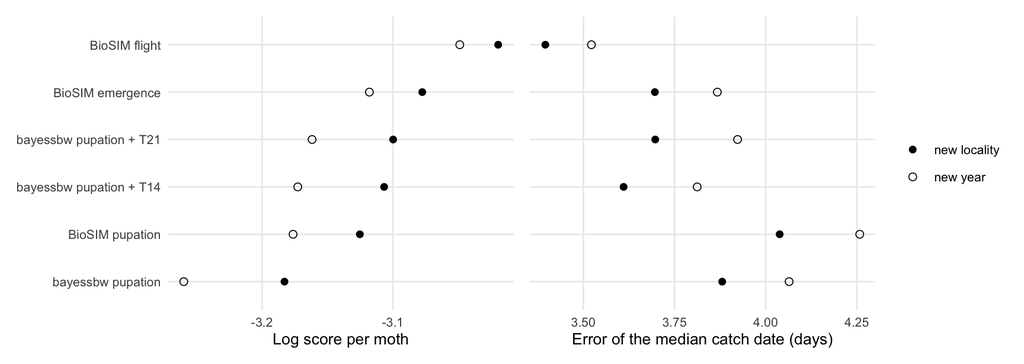

Figure 6: Centre options for the seasonal predictor: log score per moth (left, higher is better) and error of the predicted median catch date (right), for a new year and a new locality.

## 7.4 The adopted predictor

The predictor now uses BioSIM flight as its centre, and the rest is unchanged: width from the season total, a logistic curve averaged over the uncertainty of its centre.

Table 12: The adopted predictor (BioSIM flight centre, width from the season total, logistic curve), against the pupation centre it replaces

| Centre | Log score, new year | Log score, new locality | Median error, new year, d | Centre uncertainty, d |
| --- | --- | --- | --- | --- |
| BioSIM flight | -3.049 | -3.019 | 3.52 | 4.24 |
| BioSIM pupation | -3.176 | -3.125 | 4.26 | 4.88 |

Fitted on all 203 locality-years, the centre is

median catch date = 26.2 + 0.879 x (network mean of BioSIM’s median flight date) + 0.122 x (the locality’s departure from it),

with an uncertainty of 4.3 days, and the central 90% of the season is

width = 15.1 -1.21 x log10(season total) days. The lessons of Section 7 carry over to the new centre. Averaging over the centre’s uncertainty is still worth most: the score is -3.265 for a new year with the centre placed as if known. Supplying the observed width alone still makes it worse (-3.561).

## 7.5 Held-out predictions

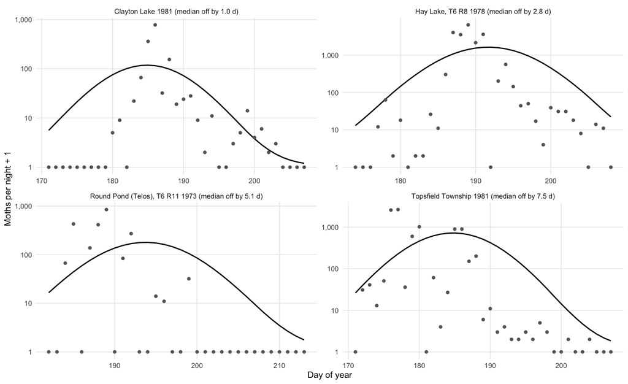

Figure 7: Held-out predictions of the adopted predictor (BioSIM flight centre, new year: each season predicted from a model fitted without its year). Line: expected catch; points: observed catches, plus one on a log scale. The four seasons of at least 1,000 moths shown are those whose error in the median catch date is closest to the 25th, 50th, 75th and 90th percentiles of that error.

## 7.6 Using the predictor

`seasonal_dynamics/R/functions/predict_season.R` holds the models fitted on all 203 locality-years, with BioSIM flight as the default driver:

```r
source("seasonal_dynamics/R/functions/predict_season.R")

predict_season(
  driver_p50         = 190.4,   # BioSIM median flight date at the locality
  driver_p50_network = 189.0,   # its mean over the trap network that year
  season_total       = 5000,    # moths caught over the season
  nights_doy         = 180:215  # nights for which shares are wanted
)
```

It returns each night’s share of the season and its expected catch, with the predicted centre, width and centre uncertainty as attributes. It needs the network mean of the driver for the year, because that carries most of the skill. With `interval = "nightly"` it also returns a prediction interval for a single night’s count, from the dispersion term of Section 9. The pupation drivers remain available through `driver = "BioSIM pupation"` or `"bayessbw pupation"`.

# 8 The local component

The adopted centre follows the differences between years closely and the differences between localities of the same year hardly at all (slope 0.122 on BioSIM’s local departure). This section asks what the remaining local part of the median catch date is made of, and whether anything available at prediction time explains it (`seasonal_dynamics/R/09_local_component.R`, the same 203 locality-years, 48 localities, 40 of them trapped in two years or more).

## 8.1 What the residual is made of

The residuals of the centre model were split by a mixed model into a year part, a persistent locality part (habitual lateness) and a locality-year remainder. The sampling variance of each observed median was measured by resampling the record’s own catch 200 times; subtracting it from the remainder leaves the transient part, a real departure of that locality in that year.

Table 13: Variance components of the median catch date, before and after the adopted centre (SD in days and share of the total). Interval: parametric bootstrap of the residual model, as SD

| Component | Observed median, SD | Share | Centre residual, SD | 95% interval | Share |
| --- | --- | --- | --- | --- | --- |
| Year | 4.23 | 0.57 | 2.18 | 1.24 to 3.07 | 0.26 |
| Locality (persistent) | 1.63 | 0.09 | 1.65 | 0.81 to 2.27 | 0.15 |
| Locality-year (transient) | 3.27 | 0.34 | 3.21 | 2.91 to 3.61 | 0.58 |
| Sampling | 0.36 | 0.00 | 0.36 |  | 0.01 |

Three things stand out.

- **Sampling error is negligible.** The median of a season is measured to within 0.36 days (SD), so the residual is not count noise.
- **The driver removes the year and nothing else.** The year SD falls from 4.23 to 2.18 days. The locality and transient components are the same before and after it.
- **Most of what is left is transient.** A locality departs from its year by 3.21 days (SD) in a way it does not repeat in other years. Habitual lateness is real but smaller (1.65 days). It is the same property that Section 6.5 found shifting a late locality’s peak and end but not its start.

## 8.2 Is the local part spatially structured?

Within a year, the residuals of two localities close together agree, and those of two localities far apart disagree (Figure 8, centre). The correlation is 0.68 under 25 km (only 7 pairs), near 0.16 between 25 and 100 km, and -0.32 beyond 200 km. Centring within a year alone would give -0.08. The same locality in two different years correlates at only 0.11. The local component is therefore a **regional pattern that changes from year to year**, not a fixed property of the sites.

A plane in latitude and longitude, fitted separately to each of the 14 years with at least six localities, explains 33% of the within-year residual variance, against 17% when the residuals are permuted among the localities of a year (p = 0.002). Most of that pattern is a north-south gradient whose strength varies between years:

- **Latitude.** The observed gradient averages +0.60 days per degree north and varies between years with an SD of 1.27 days per degree once the sampling error of each year’s slope is removed. BioSIM’s gradient averages +3.90, about 6 times steeper, and its year-to-year changes are unrelated to the observed ones (r = -0.02, Figure 8, right).
- **Longitude.** The observed gradient (-0.59 days per degree) barely changes between years (SD 0.21 net of sampling). BioSIM follows its year-to-year changes partly (r = 0.42).

BioSIM driven by CaSR temperatures thus predicts a strong, stable north-south progression of flight. The catches show a weak one that changes from year to year. That is why the fitted slope on BioSIM’s local departure is close to zero: the model’s local signal is mostly a gradient the catches do not have.

## 8.3 Can it be predicted?

Each candidate term was added to the adopted centre and scored like the centre options (Section 7.3). Every covariate entered as a departure from its year mean, so it could only act on the local component. The candidates were:

- **geography**: latitude, longitude and elevation;
- **temperature**: the local anomaly of mean CaSR temperature over 1 May to 30 June (larval development) or 15 June to 15 July (pupal and pre-flight period), two windows fixed in advance;
- **catch**: the local anomaly of the season total, already an input of the predictor;
- **habitual lateness**: a random locality intercept, the locality’s shrunken mean residual in its training years. It is known only for localities trapped before, so it can help a new year but not a new locality. A year-adjusted version estimates it net of the year errors.

Table 14: Candidate local terms added to the adopted centre. Gain: change in log score per moth of the full predictor relative to the adopted centre (positive is better). MAE: error of the median catch date; per moth: the same weighted by the season total. r within: correlation of predicted and observed departures from the year mean

| Centre | Gain, new year | MAE | MAE per moth | r within | Gain, new locality | MAE |
| --- | --- | --- | --- | --- | --- | --- |
| adopted (xY + xW) | +0.000 | 3.52 | 3.45 | +0.16 | +0.000 | 3.40 |
| + elevation | -0.000 | 3.52 | 3.46 | +0.15 | -0.000 | 3.40 |
| + temperature May-Jun | -0.002 | 3.53 | 3.46 | +0.12 | -0.003 | 3.42 |
| + temperature Jun-Jul | -0.008 | 3.54 | 3.50 | +0.12 | -0.007 | 3.42 |
| + habitual lateness | -0.011 | 3.29 | 3.56 | +0.34 | +0.002 | 3.40 |
| + geography | -0.015 | 3.60 | 3.60 | +0.04 | -0.012 | 3.48 |
| + catch | -0.022 | 3.55 | 3.53 | +0.18 | -0.032 | 3.45 |
| + habitual lateness, year-adjusted | -0.026 | 3.38 | 3.68 | +0.30 | +0.002 | 3.39 |

**No local term improves the predictor.** None raises the log score by more than 0.002, and most lower it.

- **Habitual lateness** is the only term with a visible signal. For a new year it lowers the median error from 3.52 to 3.29 days and doubles the within-year correlation (0.16 to 0.34). But the gain is in small seasons: weighted by the catch, the error rises from 3.45 to 3.56 days, and the log score, which counts every moth, falls. Separating the year errors from the locality intercept makes it worse, not better. Habitual lateness is not geographic either: latitude, longitude and elevation explain 2% of it over the 32 localities trapped in three years or more.
- **Local temperature** has no detectable effect: a locality warmer than its year by 1 °C over 15 June to 15 July flies +0.39 days later (-0.25 to +1.02). The interval includes zero, and the sign is the opposite of development. The local temperature anomalies are small (SD 0.91 °C) and carry the same CaSR information that BioSIM’s local departure already does not use.
- **Catch** is the only term whose coefficient excludes zero: a locality catching ten times more than its year flies 0.84 days earlier (-1.63 to -0.05). It does not predict out of sample.
- **Geography** adds parameters and nothing else.

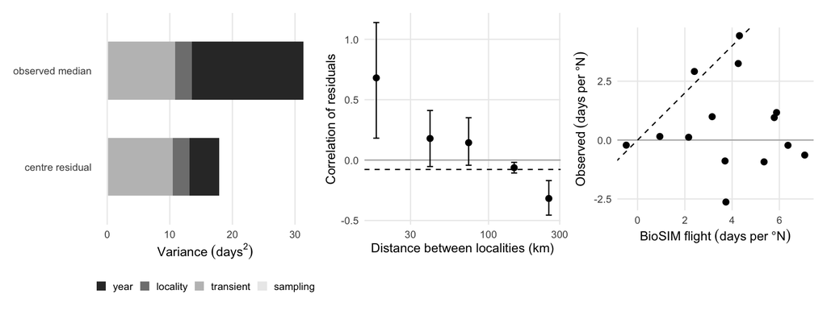

Figure 8: The local component of the median catch date. Left: variance components before and after the adopted centre. Centre: correlation of the within-year residuals of two localities trapped in the same year, by distance (bars: 95% intervals from resampling years; dashed line: the correlation produced by centring within a year alone). Right: each year’s north-south gradient of the median catch date, observed against BioSIM flight (years with six localities or more; dashed line: equality).

## 8.4 Conclusion

The adopted predictor stays as it is. Its centre uncertainty (4.3 days) is mostly this local component, and that is an honest measure of what can be said about a locality in a given year from a development model, its temperatures and its catch.

What the local component is remains open. Two explanations are consistent with the results so far:

- **Temperature at the wrong scale.** CaSR temperature at about 10 km may not resolve the conditions that set development at a trap. A test would need station records near the traps.
- **Moth movement.** Adult dispersal across the region would flatten the north-south gradient of flight relative to local development, as observed (+0.60 against +3.90 days per degree). It would also make the pattern change with each year’s winds rather than with temperature, and would let late localities start their season as early as the rest (Section 6.5). A test would need the nightly series: whether a locality’s early catches track the regional flight rather than its own development.

# 9 Nightly dispersion

Everywhere above that a season’s nights were resampled (Section 5, Section 6, Section 6.5), moths were drawn as if independent of one another, i.e. a night’s count as Binomial(season total, predicted share). The *Daily dynamics* analysis found actual nights far more variable than that (an NB2 fit around its own nightly mean curve, `daily_dynamics/R/11_count_distribution.R`). This section asks the same question of the predictor of Section 7 and Section 7.3: around the *predicted* share of a night, not its observed one.

`seasonal_dynamics/R/10_nightly_dispersion.R` treats a night’s count as Beta-Binomial(season total, predicted share, θ), the natural two-parameter family whose variance is

$$\mathrm{Var}(Y_d) = n\,p_d(1-p_d)\,\frac{n+\theta}{1+\theta}$$

the multinomial variance as θ → ∞, inflated as it falls. It is the Dirichlet-multinomial seen one night at a time, so a season’s nights still sum to its observed total. θ is fitted by maximum likelihood, as the only free parameter, against the predicted share already scored in Section 7: the leave-one-year-out prediction of the adopted predictor (BioSIM flight centre, Section 7.3), i.e. the share a user of `predict_season()` would actually be holding, not an in-sample fit.

| Model | θ | RMS standardised residual |
| --- | --- | --- |
| Multinomial (independence) | Inf (fixed) | 34.23 |
| Beta-binomial | 6.36 | 1.14 |

The fitted dispersion is θ = 6.36. A likelihood-ratio test against the multinomial (θ fixed at infinity) is decisive (3112056 on 1 df, p < 1e-10), and the standardised residual of a night’s count – which should average to 1 if the model is scaled correctly – falls from 34.2 under the multinomial to 1.14 under the beta-binomial. Treating moths as independent draws understates a night’s variability by roughly this factor.

Table 16: Variance inflation of a night’s count relative to the multinomial, (n + theta) / (1 + theta), at a few season sizes

| Season total | SD inflation (x multinomial) |
| --- | --- |
| 100 | 3.8 |
| 300 | 6.5 |
| 1,000 | 11.7 |
| 3,000 | 20.2 |
| 10,000 | 36.9 |

The inflation grows with the season total, not against it: a bigger season is not counted more precisely night to night, because the extra moths are not independent of each other. At a season of 1,000 moths a night’s realistic SD is about 12 times the multinomial’s.

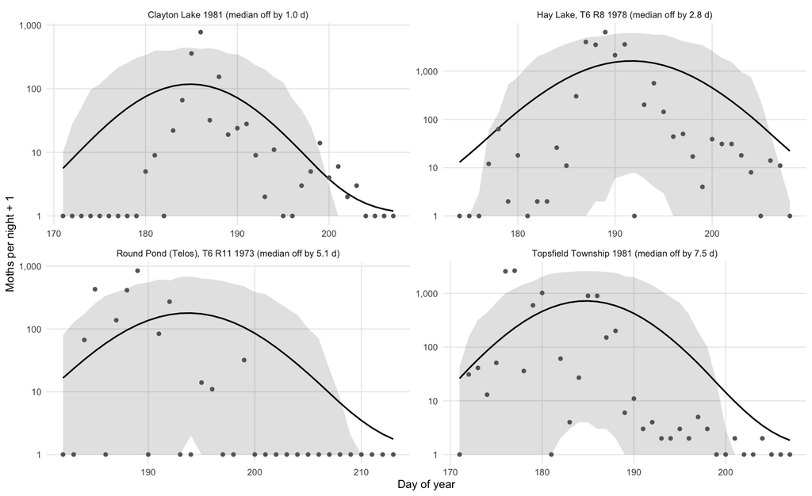

The band is wide, and mostly for a mundane reason: it is built from the *predicted* centre, so a season whose observed median misses the prediction (the usual case, Section 7.4) sits off-centre inside it rather than outside it. θ buys back some of the honesty that assuming independence would have borrowed: holding `predict_season()` to the narrower, multinomial width would understate how far a single night’s count can reasonably land around the curve’s expectation.

`predict_season()` (Section 7.4) now takes `interval = "nightly"`, returning `sd`, `lwr` and `upr` for a single night from this model. Nights are **not** independent of each other under it – they are one draw from a Dirichlet-multinomial season – so summing the per-night intervals overstates the uncertainty of a multi-night total; nothing here gives that joint interval.

This leaves the asymmetry question of Section 6.5 open rather than settled: the resampling there also treated moths as independent, and with θ this small, a run of nights sharing a warm spell could produce apparent skew that a wider null would absorb. Revisiting Section 6.5 with this dispersion, rather than the multinomial, is unfinished.

# 10 Population levels

Can the season totals be split into two classes, low and high population level? The question has to be asked of **every** record, not only of the analysis set, because the 99-moth threshold of `R/01` selects on the season total itself. `R/01` now also writes `trap_season_totals.rds`: all 457 Maine light-trap records of 1968–1989 before the threshold (404 with a daily series, 53 with a season total only), 226 of which are retained for the analyses above. 55 records caught no moth at all. They form a point mass that no continuous distribution describes, so they are set aside and reported with the year table (`seasonal_dynamics/R/10_population_classes.R`).

Three tests were applied to the log10 season totals:

- Hartigan’s **dip test**, which asks whether the distribution has more than one mode;
- **Gaussian mixtures** of one to four components, compared by BIC;
- a **bootstrap likelihood-ratio test** (999 resamples) of one component against two, and two against three.

Table 17: Tests for two population classes in the log10 season total. Dip: Hartigan’s test of unimodality. Mixture: number of Gaussian components preferred by BIC (E: equal, V: unequal variances). LRT: bootstrap likelihood-ratio test

| Records | n | Dip p | BIC components | LRT 1 vs 2, p | LRT 2 vs 3, p |
| --- | --- | --- | --- | --- | --- |
| positive totals, log10 | 402 | 0.085 | 2 (V) | 0.001 | 0.220 |
| all totals, log10(total + 1) | 457 | 0.000 | 4 (E) | 0.001 | - |
| daily series >= 20 nights, log10 | 260 | 0.931 | 2 (V) | 0.001 | 0.502 |

**The mixture models favour two components, but there are not two modes.** On the 402 positive totals, BIC prefers two components to one by 19 units, and the bootstrap rejects one component (p = 0.001) but not two (p = 0.22 for a third). The fitted mixture has two peaks and a trough between them, at about 680 moths (Figure 10, left). But the trough is shallow: the density there is 78% of the lower peak. The dip test, the direct test of two modes in the data rather than in a fitted model, does not reject a single mode (p = 0.085). The components are:

- **low**: median 47 moths, SD 0.88 log units, 70% of seasons;
- **high**: median 4396 moths, SD 0.52 log units, 30% of seasons.

One component is broad and the other narrow. Such a pair also describes a single skewed distribution, a long tail of small catches below a concentration of large ones. A mixture can prefer two components without the data holding two populations, so the evidence for two classes is suggestive, not conclusive.

**Part of the low tail is trapping effort.** Among records with a daily series, the log season total correlates 0.59 with the log number of nights trapped. Low-class records were trapped for a median of 20 nights, against 27 for high-class records. Restricted to the 260 records trapped 20 nights or more, the distribution is plainly unimodal (dip p = 0.93). Including the zero seasons makes the dip test significant (p < 0.001), but only because of the spike of 55 zeros. It is not evidence of a second population.

**The population level is mostly a property of the year.** Of the variance in log10(total + 1), the year accounts for 50%, the locality for 28%, and the locality-year remainder for 21% (Figure 10, right). The years trace the outbreak cycle continuously rather than in two states:

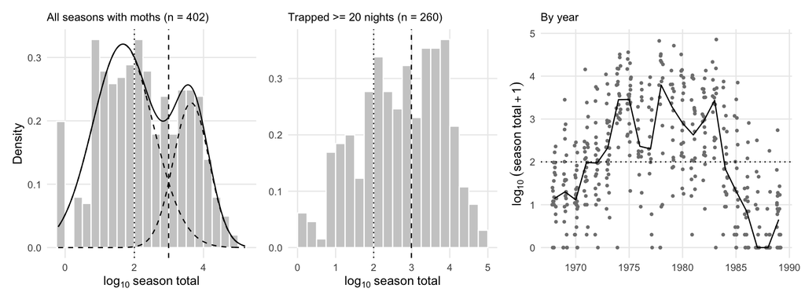

Figure 10: Season totals of all Maine light-trap records, 1968-1989, before the 99-moth threshold. Left: distribution of the log10 total of seasons with at least one moth, with the two-component mixture (dashed: components; solid: their sum); vertical lines: the 99-moth threshold (dotted) and the boundary where a season is equally likely to belong to either component (dashed). Centre: the same for records trapped at least 20 nights. Right: every record by year (zero seasons plotted at 0), with the year median.

# 11 Next steps

1. **The origin of the local component** (Section 8), if it matters for the use of the predictor: station temperatures near the traps, or the nightly series, to tell temperature at the wrong scale from moth movement.
2. **Nightly variability**, if prediction intervals for single nights are wanted: a dispersion term on top of the seasonal curve. Done (Section 9): a beta-binomial term, fitted on the predictor’s own held-out predictions. The resampling used earlier in this analysis (Section 5, Section 6, Section 6.5) treats moths as independent draws; this section shows that nights are considerably more variable than that, consistent with the Daily dynamics analysis’s NB2 fit (`daily_dynamics/R/11_count_distribution.R`).